# LeadingCauseOfDeath.Rmd

Herbert Gutierrez, Ryan Wechter

October 1, 2015

## Loading our data from the Oracle Database

We modified the R script given to us to create a SQL code that would create the table in the Oracle Database. We then loaded our data and could connect to the database to create our data frame in RStudio.

```r
source("../02 Data Wrangling/Project2_ETL.R", echo = TRUE)
```

```
##
## > require("ggplot2")
```

```
##
## > require("gplots")
```

```
##
## > require("grid")
```

```
##
## > require("RCurl")
```

```
##
## > require("reshape2")
```

```
##
## > require("tableplot")
```

```
##
## > require("tidyr")
```

```
##
## > require("dplyr")
```

```
##
## > require("jsonlite")
```

```
##
## > require("lubridate")
```

```
##
## > df <- data.frame(fromJSON(getURL(URLencode("129.152.144.84:5001/rest/native/?query=\"select * from COD\""),
## +     httpheader = c(DB = "jdbc:oracle: ..." ... [TRUNCATED]
##
## > summary(df)
##                                              X113_CAUSE_NAME
##  Accidents (unintentional injuries) (V01-X59,Y85-Y86): 780
##  All Causes                                          : 780
##  Alzheimers disease (G30)                            : 780
##  Chronic liver disease and cirrhosis (K70,K73-K74)   : 780
##  Chronic lower respiratory diseases (J40-J47)        : 780
##  Diabetes mellitus (E10-E14)                         : 780
##  (Other)                                             :6802
##                                CAUSE_NAME             STATE
##  All Causes                         : 780   Wisconsin    :  239
##  Alzheimers disease                 : 780   United States:  237
##  Cancer                             : 780   Utah         :  237
##  Chronic liver disease and cirrhosis: 780   Washington   :  237
##  CLRD                               : 780   West Virginia:  237
##  Diabetes                           : 780   Tennessee    :  235
##  (Other)                            :6802   (Other)      :10060
##       YEAR          DEATHS             AADR
##  Min.   :1999   Min.   :     20   Min.   :   1.38
##  1st Qu.:2002   1st Qu.:    332   1st Qu.:   9.75
##  Median :2006   Median :    986   Median :  21.14
##  Mean   :2006   Mean   :  11537   Mean   :  97.94
##  3rd Qu.:2010   3rd Qu.:   3104   3rd Qu.:  49.68
##  Max.   :2013   Max.   :2596993   Max.   :1087.30
##
##
## > head(df)
##                                X113_CAUSE_NAME CAUSE_NAME
## 1 Chronic lower respiratory diseases (J40-J47)       CLRD
## 2 Chronic lower respiratory diseases (J40-J47)       CLRD
## 3 Chronic lower respiratory diseases (J40-J47)       CLRD
## 4 Chronic lower respiratory diseases (J40-J47)       CLRD
## 5 Chronic lower respiratory diseases (J40-J47)       CLRD
## 6 Chronic lower respiratory diseases (J40-J47)       CLRD
##                  STATE YEAR DEATHS  AADR
## 1             Delaware 1999    327 42.74
## 2 District of Columbia 1999    166 29.89
## 3              Florida 1999   9131 43.08
## 4              Georgia 1999   3056 49.06
## 5               Hawaii 1999    290 24.01
## 6                Idaho 1999    568 49.54
```

## Graph 1: Selected Causes of Death in Texas (1999-2013)

```
##
## > df %>% select(CAUSE_NAME, STATE, AADR, YEAR) %>% filter(STATE ==
## +     "Texas", (CAUSE_NAME == "Diabetes" | CAUSE_NAME == "Diseases of Heart" |
## +  .... [TRUNCATED]
```

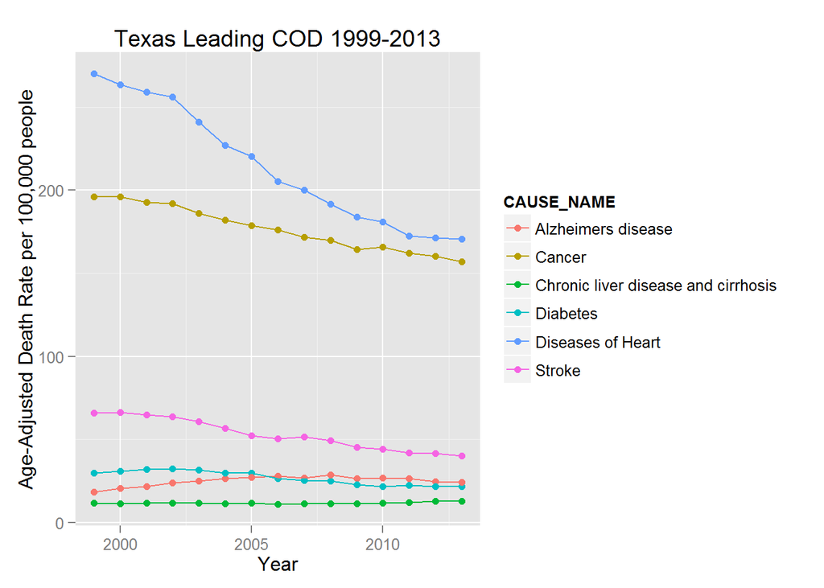

```r
source("../02 Data Wrangling/Graph1.R", echo = TRUE)
```

#### Interpretation

This Graph shows the selected causes of death in Texas from 1999-2013 per 100,000 people. One can clearly see that heart disease is the highest value throughout the years followed by cancer. Furthermore, there is a decrease of these two values as the years progress. This can be due to the fact that a significant amount of research, medical advances, and general awareness have been able to reduce the amount of deaths. However, when looking at something like Alzheimer’s disease which has not had that many medical breakthroughts, it has remained relatively the same.

## Graph 2: Selected States’ Death Rates (1999-2013)

```
##
## > df %>% select(STATE, YEAR, CAUSE_NAME, AADR) %>% filter(STATE ==
## +     "United States" | STATE == "Texas" | STATE == "District of Columbia" |
## +    .... [TRUNCATED]
```

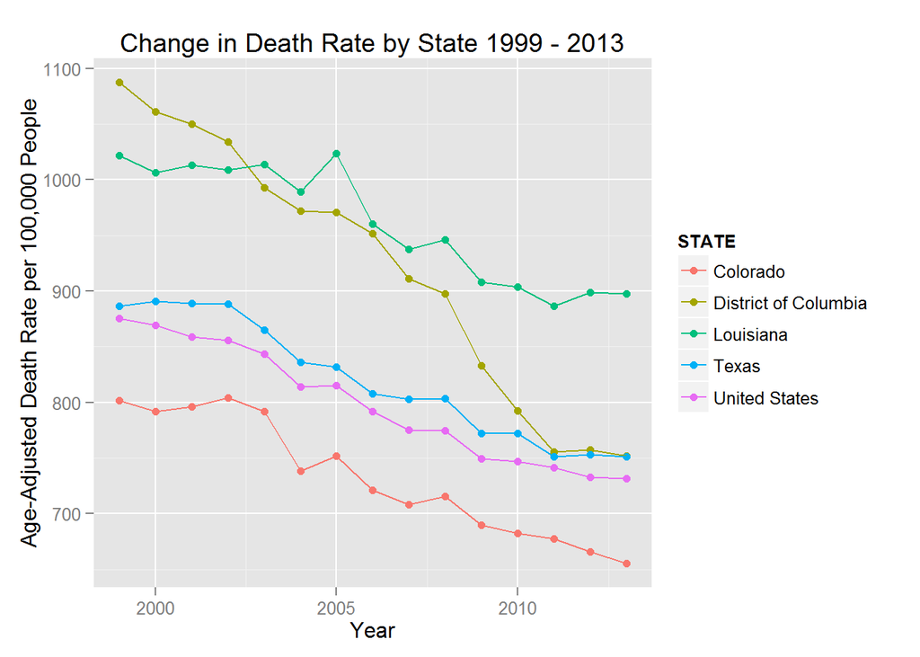

```r
source("../02 Data Wrangling/Graph2.R", echo = TRUE)
```

## Graph 3: Suicide Rates in 2013 for all states

```
##
## > df %>% select(STATE, AADR, YEAR, CAUSE_NAME) %>% filter(CAUSE_NAME ==
## +     "Suicide", YEAR == "2013") %>% ggplot(aes(x = reorder(STATE,
## +     AAD .... [TRUNCATED]
```

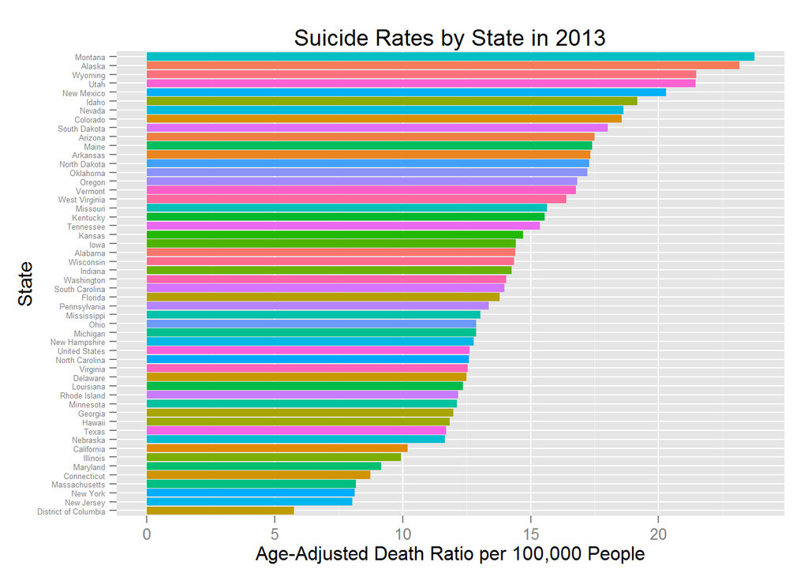

```r
source("../02 Data Wrangling/Graph3.R", echo = TRUE)
```

#### Interpretation

This bar graphs shows the number of suicides per 100,000 people in each state in 2013. From the graph Montana has the highest suicide rate followed by Alaska, while New Jersey and the District of Columbia have the lowest. Texas also seems to be one of the states with the lowest suicide rates in 2013.